# Introduction to Spatial Analysis

Day 4 - Measurement

Jonathan Phillips

January, 2019

## Spatial Measurement

- What patterns in our data do we want to measure?
  - Where events take place?
  - Whether events are ‘clustered’ in space
  - Whether attitudes are ‘clustered’ together (given fixed locations)
  - Whether groups are ‘segregated’

## Measures of Central Tendency

- What is the ‘average’ place where violence occurs in a city?
- What is the ‘average’ place where protests happen?
- We use the ‘centroid’, the average of all points’ coordinates
  - Remember, nothing may happen at the average itself

## Measures of Central Tendency

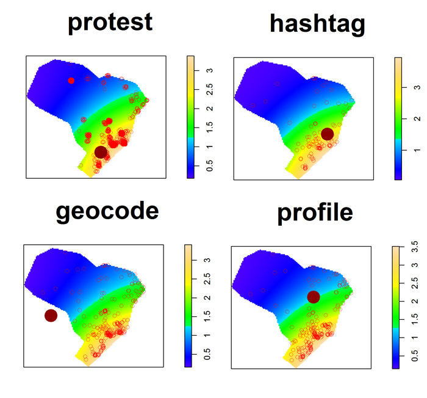

Centre of Mass of Brazilian Protests, 2013. Source: Bastos et al 2014

## Measures of Central Tendency

- We can also measure the ‘distribution’ of spatial events in two-dimensions
  - A ‘spatial ellipse’
  - Location, dispersion and direction

## Measures of Central Tendency

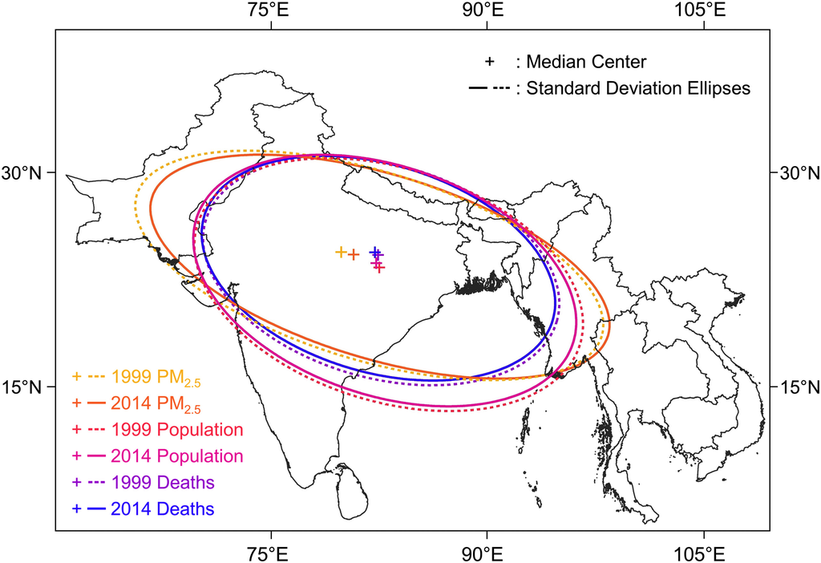

Population and Mortality in South Asia, Shi et al 2018

## Spatial Point Patterns

- Is the location of protests random? Or do protestors target specific places?
- Is the distribution of hospitals in a city uniform or biased?
- We can calculate the number of ‘events’ (points) per $km^2$
  - But is the ‘expected frequency’ of an event constant across space?
  - Often crucial to take into account the background population

## Spatial Point Patterns

- Our null hypothesis is of ‘complete spatial randomness’
  - Each location has an equal probability of an event occurring (poisson model)
  - How far away is our distribution of points from this random distribution?
  - Simple statistical test

## Spatial Point Patterns

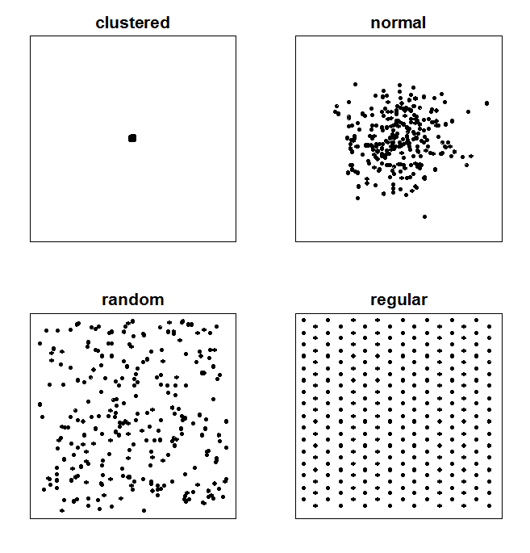

## Spatial Point Patterns

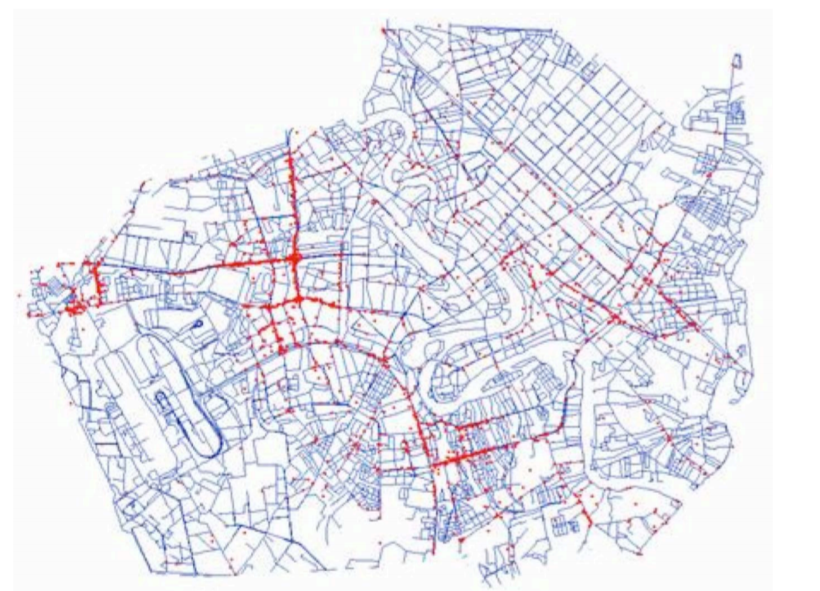

Location of Baghdad IEDs. Source: Anselin N.D.

## Clustering vs. Segregation

## Neighbours

- Remember the First Law of Geography?
- Spatial analysis depends on some units being closer to each other than others
- But when am I ‘closer’ to you?
  - ‘Neighbours’ are other units that are considered ‘closer’

## Neighbours

1. Contiguity-based Neighbours
- For polygons, contiguity means ‘touching’

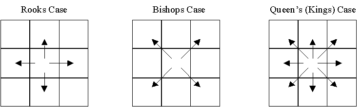

## Neighbours

2. Distance-based Neighbours
   - Nearest-neighbour
   - Might not be ‘close’, but is ‘closer’

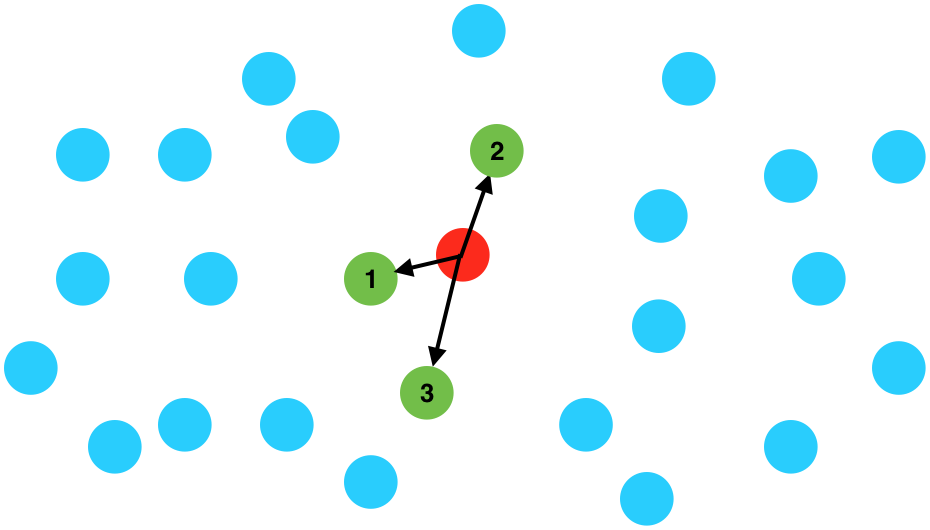

## From Neighbours to Spatial Weights